# Accessibilité et Potentiel

# **3. Exploration cartographique**

Nous allons préparer une série de trois fonctions facilitant la préparation des fichiers dont nous aurons besoin pour notre application shiny

### Contour des communes

On suppose que notre application permettra de sélectionner une liste finie de communes dont on veut avoir les contours. Selon les besoins, les coordonnées pourront adopter différentes projections.

```r
# mapcom<-readRDS(file = 'com.RDS')
extract_map <- function(mapcom = mapcom, mycom = c("94071"), myproj = 2154) {

    map <- mapcom %>%
        filter(CODE_COM %in% mycom) %>%
        st_transform(crs = myproj)

    return(map)
}
```

Nous essayons d’appliquer notre fonction à la cartographie d’un ensemble de communes de l’est du val de Marne :

```r
selcom <- c("94071", "94055", "94019", "94053", "94059", "94060", "94079", "94017",
    "94068", "94011")
mymap <- extract_map(mapcom = mapcom, mycom = selcom, myproj = 2154)
kable(head(mymap))
```

| CODE_COM | NOM_COM | CODE_EPT | geometry |
| --- | --- | --- | --- |
| 94011 | Bonneuil-sur-Marne | T11 Grand Paris Sud Est Avenir | POLYGON ((661486.3 6851863,… |
| 94017 | Champigny-sur-Marne | T10 Paris-Est-Marne et Bois | POLYGON ((667140.1 6856088,… |
| 94019 | Chennevières-sur-Marne | T11 Grand Paris Sud Est Avenir | POLYGON ((667796.6 6855072,… |
| 94053 | Noiseau | T11 Grand Paris Sud Est Avenir | POLYGON ((666202.7 6851862,… |
| 94055 | Ormesson-sur-Marne | T11 Grand Paris Sud Est Avenir | POLYGON ((664632 6853996, 6… |
| 94059 | Le Plessis-Trévise | T11 Grand Paris Sud Est Avenir | POLYGON ((669602.5 6854877,… |

On cartographie avec mapsf

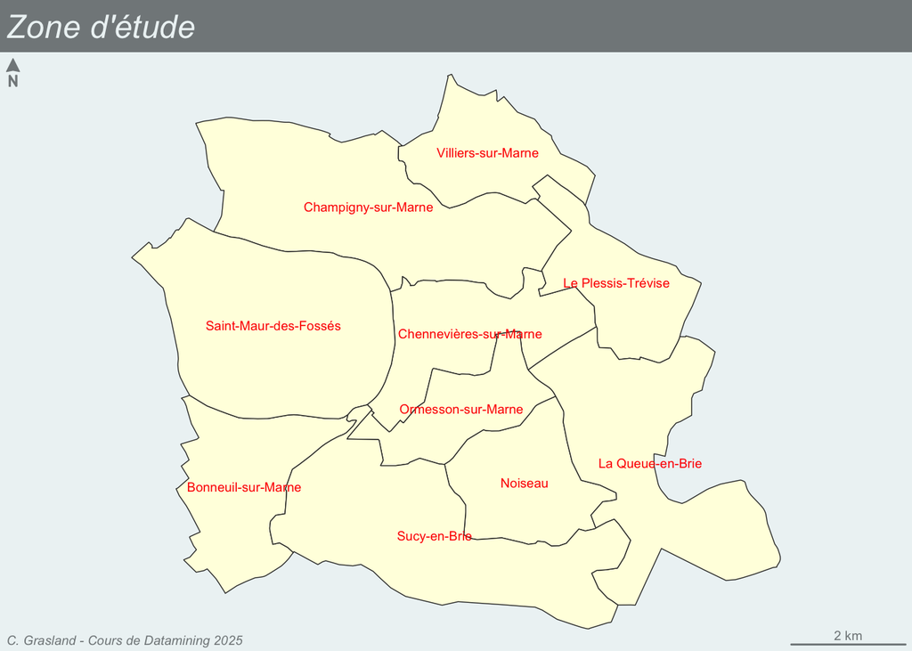

```r
mf_init(mymap, theme = "agolalight")

mf_map(mymap, type = "base", col = "lightyellow", add = T)

mf_label(mymap, var = "NOM_COM", cex = 0.6, overlap = F, col = "red")

mf_layout(title = "Zone d'étude", credits = "C. Grasland - Cours de Datamining 2025")
```

### Distribution de la population

Nous créons une fonction qui permet de préparer facilement un fichier de points localisés au centre des grilles, valués par une population, avec deux systèmes de coordonnées projetées ou non projetées.

```r
extract_pop<- function(mypop = gridpop,
                       mycom = c("94071"),
                       mysize = "Ind",
                       myproj = 2154) {

## Sélectionne les points de grille et les masses
pop <- mypop %>% filter(Depcom %in% mycom) %>%  # sélection des communes
                select(Mi = mysize) %>%            # sélection de la masse
                st_transform(crs=myproj) %>%       # projection
                st_centroid()                    # calcul des centres

## Ajoute un identifiant
pop$i<-1:nrow(pop)

## Ajoute les coordonnées projetées (pour mapsf)
coo<-st_coordinates(pop)
pop$Xi<-coo[,1]
pop$Yi<-coo[,2]

## Ajoute les coordonnées non projetées (pour leaflet)
coo2<-st_coordinates(st_transform(pop,crs=4326))
pop$LONi<-coo2[,1]
pop$LATi<-coo2[,2]

## Réordonne les variables
pop <- pop %>% select(i,Mi, Xi,Yi,LONi,LATi,geometry)

## renvoie le résultat
return(pop)
}
```

Nous essayons d’appliquer notre fonction sur la distribution de la population de 6-10 ans de notre zone d’étude

```r
mypop <- extract_pop(mypop = gridpop, mycom = selcom, mysize = "Ind_6_10", myproj = 2154)
kable(head(mypop))
```

| i | Mi | Xi | Yi | LONi | LATi | geometry |
| --- | --- | --- | --- | --- | --- | --- |
| 1 | 6 | 667278.1 | 6851223 | 2.554858 | 48.76028 | POINT (667278.1 6851223) |
| 2 | 9 | 661415.5 | 6855881 | 2.474685 | 48.80186 | POINT (661415.5 6855881) |
| 3 | 3 | 665554.2 | 6852463 | 2.531307 | 48.77135 | POINT (665554.2 6852463) |
| 4 | 142 | 661769.7 | 6852101 | 2.479847 | 48.76788 | POINT (661769.7 6852101) |
| 5 | 2 | 666706.3 | 6855183 | 2.546770 | 48.79587 | POINT (666706.3 6855183) |
| 6 | 23 | 665952.6 | 6852502 | 2.536725 | 48.77171 | POINT (665952.6 6852502) |

On essaye maintenant de représenter la distribution des enfants de 6-10 ans avec mapsf :

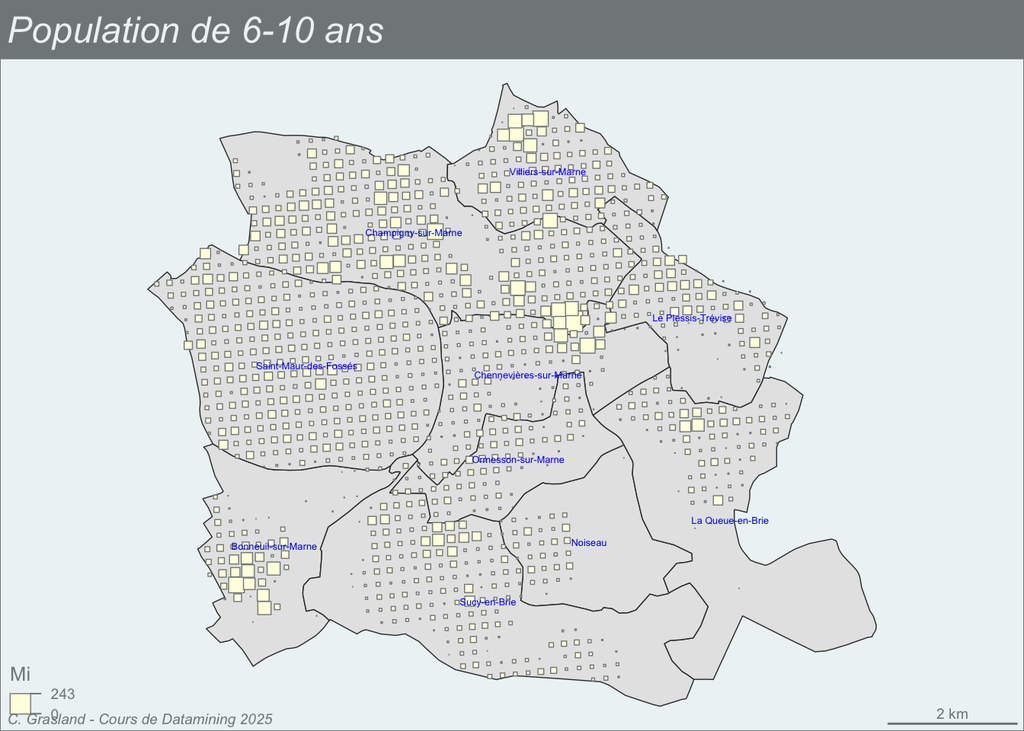

```r
mf_init(mymap, theme = "agolalight")

mf_map(mymap, theme = "agolalight", type = "base", col = "gray90", add = T)

mf_map(mypop, type = "prop", var = "Mi", inches = 0.07, symbol = "square", col = "lightyellow",
    )

mf_label(mymap, var = "NOM_COM", cex = 0.4, overlap = F, col = "blue")

mf_layout(title = "Population de 6-10 ans", frame = T, credits = "C. Grasland - Cours de Datamining 2025",
    arrow = F)
```

### Localisation des commerces et services

Nous créons une fonction qui permet d’extraire un type particulier d’équipement à destination de la population précédemment définie. Dans le cas des 6-10 ans, on va positionner les écoles primaires de la zone d’étude.

```r
extract_equ<- function(equip = bpe,
                       mycom = c("94071"),
                       myequ = "C104",
                       myproj = 2154) {

## Sélectionne les points de grille et les masses
equ <- equip %>% filter(DEPCOM %in% mycom) %>%  # sélection des communes
               filter(TYPEQU == myequ)%>%
               mutate(Ej = 1) %>%            # sélection de l'équipement
               st_transform(crs=myproj) %>%       # projection
               st_centroid()                    # calcul des centres

## Ajoute un identifiant
equ$j<-1:nrow(equ)

## Ajoute les coordonnées projetées (pour mapsf)
coo<-st_coordinates(equ)
equ$Xj<-coo[,1]
equ$Yj<-coo[,2]

## Ajoute les coordonnées non projetées (pour leaflet)
coo2<-st_coordinates(st_transform(equ,crs=4326))
equ$LONj<-coo2[,1]
equ$LATj<-coo2[,2]

## Réordonne les variables
equ <- equ %>% select(j,Ej, Xj,Yj,LONj,LATj,geometry)

## renvoie le résultat
return(equ)
}
```

Nous essayons d’appliquer notre fonction sur la distribution des écoles élémentaires de notre zone d’étude

```r
myequ <- extract_equ(equip = bpe, mycom = selcom, myequ = "C104", myproj = 2154)

kable(head(myequ))
```

| j | Ej | Xj | Yj | LONj | LATj | geometry |
| --- | --- | --- | --- | --- | --- | --- |
| 1 | 1 | 661745.2 | 6852290 | 2.479497 | 48.76957 | POINT (661745.2 6852290) |
| 2 | 1 | 662382.0 | 6852901 | 2.488107 | 48.77511 | POINT (662382 6852901) |
| 3 | 1 | 662104.4 | 6852789 | 2.484339 | 48.77408 | POINT (662104.4 6852789) |
| 4 | 1 | 661741.6 | 6851979 | 2.479475 | 48.76678 | POINT (661741.6 6851979) |
| 5 | 1 | 662210.5 | 6851649 | 2.485884 | 48.76384 | POINT (662210.5 6851649) |
| 6 | 1 | 661720.6 | 6852325 | 2.479159 | 48.76989 | POINT (661720.6 6852325) |

On essaye maintenant de représenter la distribution des écoles par rapport à celle des élèves avec mapsf :

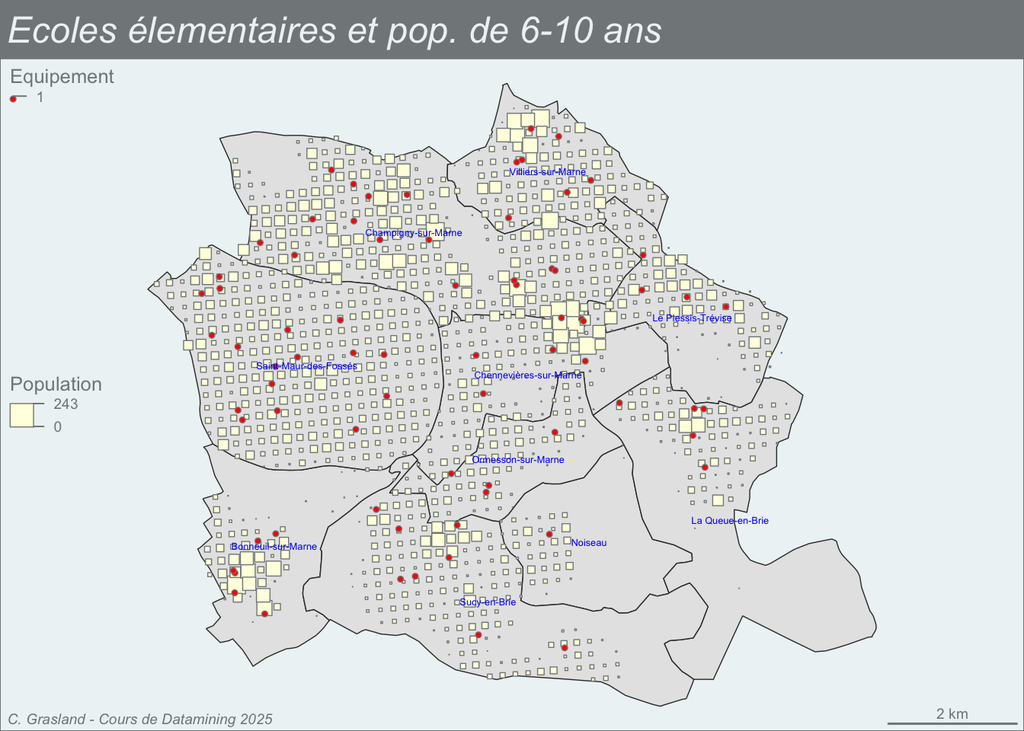

```r
mf_init(mymap, theme = "agolalight")

mf_map(mymap, theme = "agolalight", type = "base", col = "gray90", add = T)

mf_map(mypop, type = "prop", var = "Mi", symbol = "square", inches = 0.08, col = "lightyellow",
    leg_pos = "left", leg_title = "Population")

mf_map(myequ, type = "prop", var = "Ej", symbol = "circle", inches = 0.02, col = "red",
    leg_pos = "topleft", leg_title = "Equipement")

mf_label(mymap, var = "NOM_COM", cex = 0.4, overlap = F, col = "blue")

mf_layout(title = "Ecoles élementaires et pop. de 6-10 ans", frame = T, credits = "C. Grasland - Cours de Datamining 2025",
    arrow = F)
```

### Une fonction pour les gouverner tous

On reprend le programme précédent pour en faire une fonction de cartographie semi-automatique :

```r
map_pop_equ <- function(map = mymap, nommap = "NOM_COM", pop = mypop, nompop = "Population",
    equ = myequ, nomequ = "Equipement", titre = "Population et équipement", source = "Cours de DataMining 2022") {
    mf_init(map, theme = "agolalight")

    mf_map(map, theme = "agolalight", type = "base", col = "gray90", add = T)

    mf_map(pop, type = "prop", var = "Mi", symbol = "square", inches = 0.08, col = "lightyellow",
        leg_pos = "topright", leg_title = nompop)

    mf_map(equ, type = "prop", var = "Ej", symbol = "circle", inches = 0.02, col = "red",
        leg_pos = "topleft", leg_title = nomequ)

    if (is.na(nommap) == FALSE) {
        mf_label(map, var = nommap, cex = 0.4, overlap = F, col = "blue")
    }

    mf_layout(title = titre, frame = T, credits = source, arrow = F)
}
```

### Test des fonctions

Pour tester nos différentes fonction, nous allons les appliquer aux cas d’une cartographie de la localisation des pharmacies de la rive gauche de Paris par rapport à l’ensemble de la population

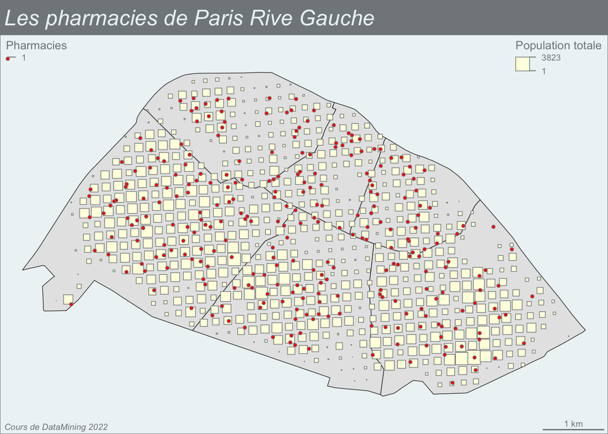

```r
selcom <- c("75105", "75106", "75107", "75113", "75114", "75115")
selequ <- "D307"
selpop <- "Ind"


mymap2 <- extract_map(mapcom = mapcom, mycom = selcom, myproj = 2154)
myequ2 <- extract_equ(equip = bpe, mycom = selcom, myproj = 2154, myequ = "D307")
mypop2 <- extract_pop(mypop = gridpop, mycom = selcom, myproj = 2154, mysize = "Ind")


map_pop_equ(map = mymap2, nommap = NA, pop = mypop2, nompop = "Population totale",
    equ = myequ2, nomequ = "Pharmacies", titre = "Les pharmacies de Paris Rive Gauche")
```

# **4. Accessibilité spatiale**

On va s’intéresser ici à la distance minimale d’accès à un service. Soit de façon purement géométrique en considérant la distance de chaque point au service. Soit de façon opérationelle en considérant la distance de la population concernée au service

On commence par examiner la distance à l’école la plus proche en fonction de la localisation spatiale c’est-à-dire de la position en un point habité ou non du territoire.

### Etape 1 : Création d’une grille de points

On définit un contour de la zone d’étude recouvrant tous les points pour lesquels on souhaite mesurer l’accessiblité

```r
mycont <- mymap %>%
    summarize() %>%
    st_as_sf()
```

```r
mygrid <- create_grid(x = mycont, res = 200)
```

### Etape 2 : Calcul des distances minimales

On calcule l’accessibilité des points de la grille à l’école la plus proche en calculant la matrice de distance entre tous les points de grille (en ligne) et tous les équipements (en colonne) puis en retenant la distance la plus courte (minimum de chaque ligne de la matrice).

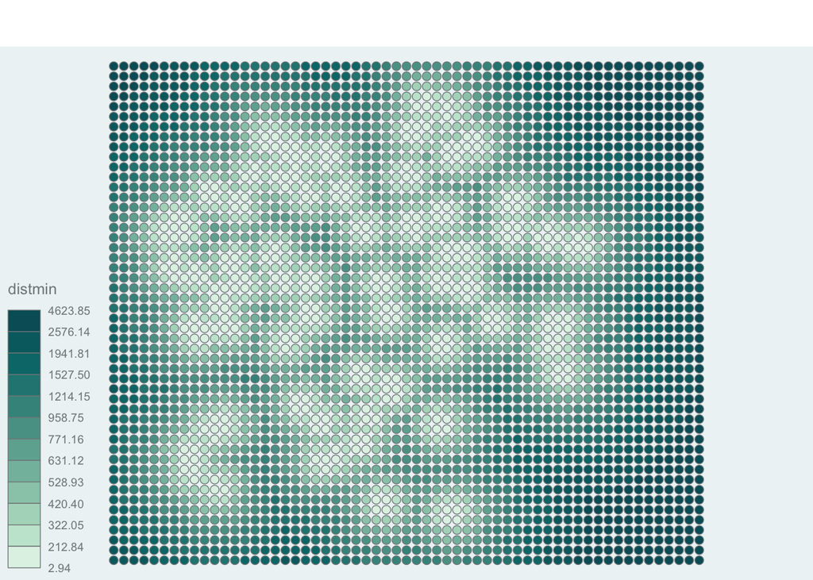

```r
d <- create_matrix(x = mygrid, y = myequ)
mygrid$distmin <- apply(d, 1, min)
mf_map(mygrid, type = "choro", var = "distmin")
```

### Etape 3 : Calcul des lignes d’isopotentiel

On choisit des seuils de distance correspondant aux valeurs de distance que l’on souhaite représenter par des isolignes et on extrait uniquement les surfaces comprises dans la zone d’étude

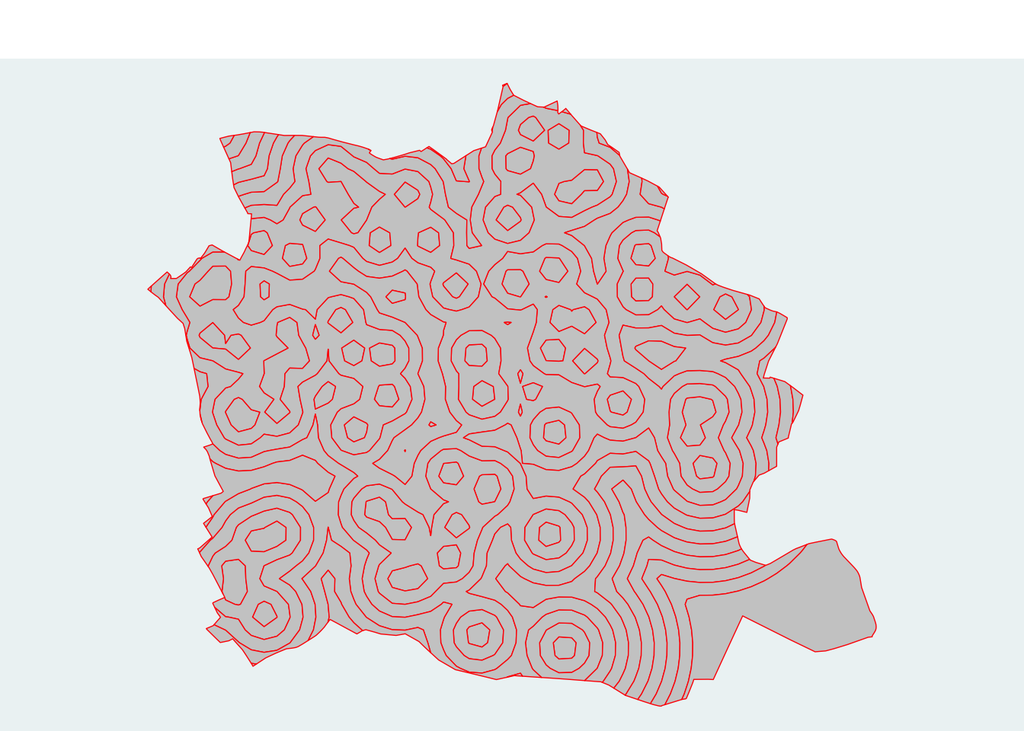

```r
mybreaks <- seq(0, 2000, 200)
iso <- equipotential(mygrid, var = "distmin", breaks = mybreaks, mask = mycont)
mf_map(iso, type = "base", border = "red")
```

### Etape 4 : Assemblage de la carte

On réalise finalement une jolie carte en combinant différentes couches à l’aide de mapsf :

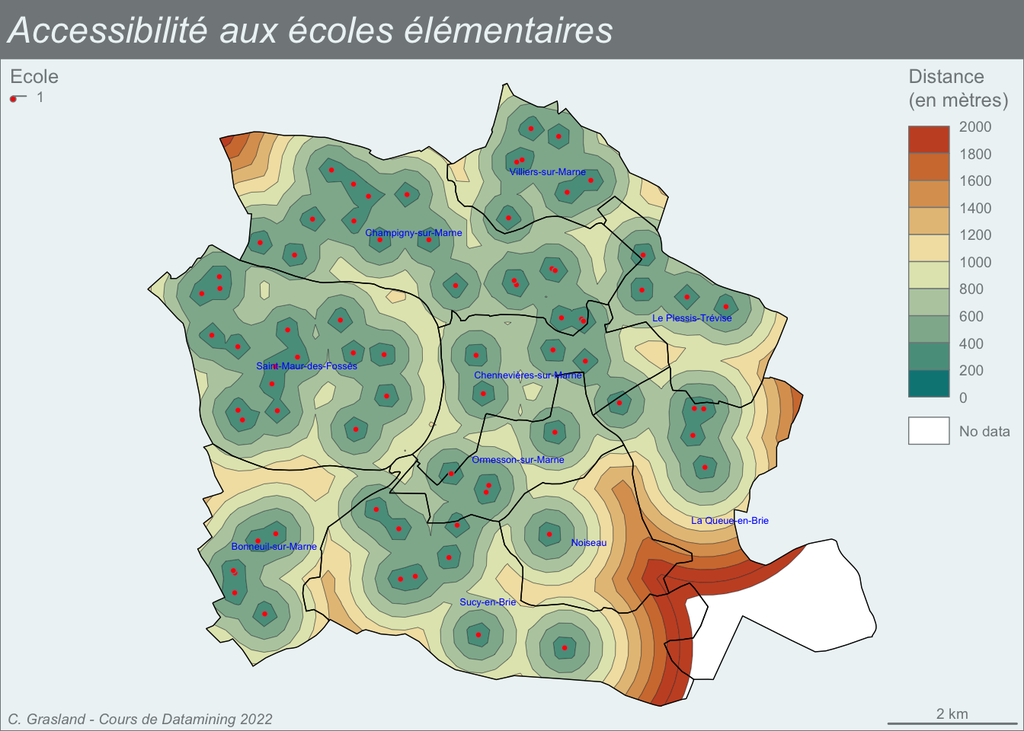

```r
mf_init(mymap, theme = "agolalight")

mf_map(x = iso, var = "max", type = "choro", breaks = mybreaks, pal = hcl.colors(10,
    "Geyser"), lwd = 0.2, border = "#121725", leg_pos = "topright", leg_val_rnd = 0,
    leg_title = "Distance \n(en mètres) ", add = T)

mf_map(mymap, theme = "agolalight", type = "base", col = NA, border = "black", add = T)

mf_map(myequ, type = "prop", var = "Ej", symbol = "circle", inches = 0.02, col = "red",
    leg_pos = "topleft", leg_title = "Ecole")

mf_layout(title = "Accessibilité aux écoles élémentaires", frame = T, credits = "C. Grasland - Cours de Datamining 2022",
    arrow = F)

mf_label(mymap, var = "NOM_COM", cex = 0.4, overlap = F, col = "blue")
```

### Etape 5 : création d’une fonction

On va reprendre toutes les étapes dans une fonction :

```r
map_equ_dist <- function(map = mymap, nommap = NA, equ = myequ, nomequ = "Equipement",
    myres = 200, mybreaks = mybreaks, mypal = mypal, titre = "Accessibilité", source = "Cours de DataMining 2022") {

    mycont <- map %>%
        summarize() %>%
        st_as_sf()
    mygrid <- create_grid(x = mycont, res = myres)
    d <- create_matrix(x = mygrid, y = equ)
    mygrid$distmin <- apply(d, 1, min)
    iso <- equipotential(mygrid, var = "distmin", breaks = mybreaks, mask = mycont)

    mf_init(map, theme = "agolalight")

    mf_map(x = iso, var = "max", type = "choro", breaks = mybreaks, pal = mypal,
        lwd = 0.2, border = "#121725", leg_pos = "topright", leg_val_rnd = 0, leg_title = "Distance \n(en mètres) ",
        add = T)

    mf_map(map, theme = "agolalight", type = "base", col = NA, border = "black",
        add = T)

    mf_map(equ, type = "prop", var = "Ej", symbol = "circle", inches = 0.02, col = "red",
        leg_pos = "topleft", leg_title = nomequ)

    mf_layout(title = titre, frame = T, credits = source, arrow = F)

    if (is.na(nommap) == FALSE) {
        mf_label(map, var = nommap, cex = 0.4, overlap = F, col = "blue")
    }

}
```

Essayons de faire une carte de l’accessibilité aux pharmaciesde Paris Rive Gauche

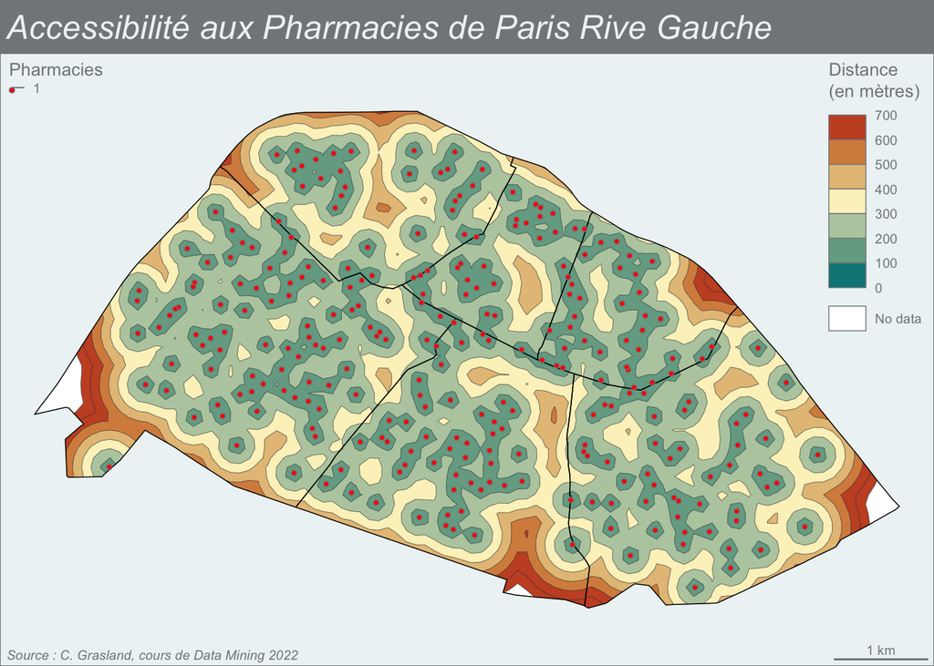

```r
selcom <- c("75105", "75106", "75107", "75113", "75114", "75115")
mybreaks <- c(0, 100, 200, 300, 400, 500, 600, 700)
mypal <- hcl.colors(7, "Geyser")

myequ2 <- extract_equ(equip = bpe, mycom = selcom, myproj = 2154, myequ = "D307")
mypop2 <- extract_pop(mypop = gridpop, mycom = selcom, myproj = 2154, mysize = "Ind")
map_equ_dist(map = mymap2, equ = myequ2, nomequ = "Pharmacies", myres = 100, mybreaks = mybreaks,
    mypal = mypal, titre = "Accessibilité aux Pharmacies de Paris Rive Gauche",
    source = "Source : C. Grasland, cours de Data Mining 2022")
```

# **5. Inégalités d’accès**

Dans le cas précédent, on ne s’intéressait pas à la position des habitants par rapport aux services. Mais il faut évidemment en tenir compte puisque l’absence de service n’est pas un problème dans les zones inhabitées comme la forêt Notre-Dame au sud-est de la carte. Ce qu’il faut plutôt identifier dans une logique de service public ce sont les zones habitées mais éloignées des services indispensables.

### Etape 1 : Calcul des distances de la population à un service

On calcule l’accessibilité des habitants **concernés** à l’équipement la plus proche. Dans notre exemple des écoles primaires, la population concernée est la tranche des 6-10 ans. On va donc calculer la distance de chaque points habité à l’école la plus proche.

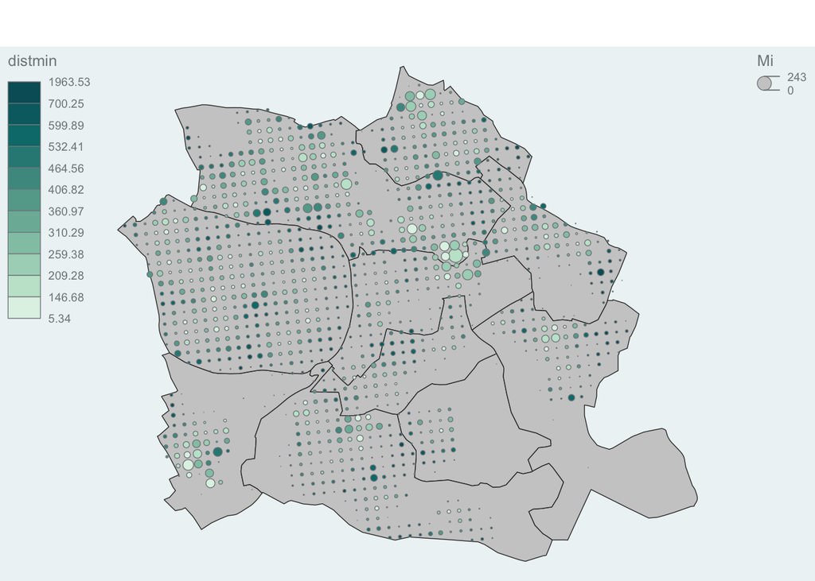

```r
d <- create_matrix(x = mypop, y = myequ)
mypop$distmin <- apply(d, 1, min)

# carto rapide
mf_map(mymap)
mf_map(mypop, type = "prop_choro", var = c("Mi", "distmin"), inches = 0.06, leg_pos = c("topright",
    "topleft"))
```

### Etape 2 : Distribution de la population / distance

On réalise une courbe de fréquence cumulée indiquant la part de la population ayant accès au service en fonction de la distance que cette population est prête à franchir. On calcule par ailleurs la distance moyenne de la population au service concerné.

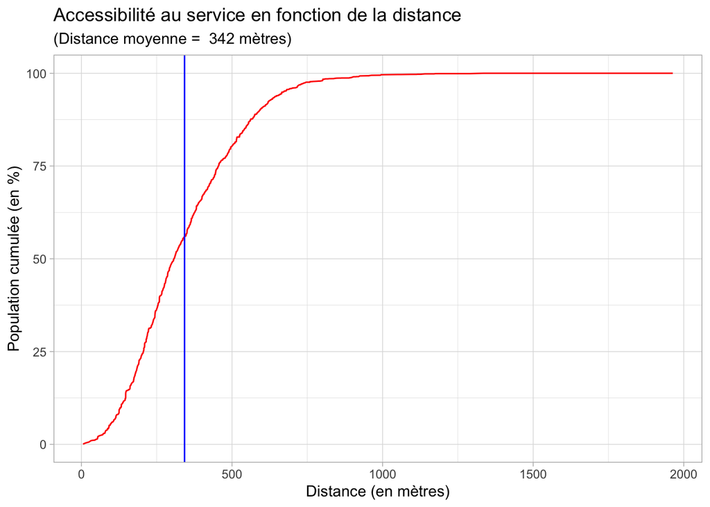

```r
tab <- st_drop_geometry(mypop) %>%
    select(Mi, distmin) %>%
    arrange(distmin) %>%
    mutate(freq = 100 * Mi/sum(Mi)) %>%
    mutate(freqcum = cumsum(freq))

distmoy <- sum(tab$distmin * tab$Mi)/sum(tab$Mi)
distmax <- max(tab$distmin)

ggplot(tab, aes(x = distmin, y = freqcum)) + geom_line(col = "red") + scale_x_continuous("Distance (en mètres)") +
    scale_y_continuous("Population cumulée (en %)") + ggtitle(label = "Accessibilité au service en fonction de la distance",
    subtitle = paste("(Distance moyenne = ", round(distmoy, 0), "mètres)")) + geom_vline(xintercept = distmoy,
    color = "blue") + theme_light()
```

### Etape 3 : création d’une fonction graphique

On automatise la création d’une graphique à l’aide d’une fonction :

```r
graph_pop_equ_dist <- function(pop = mypop, equ = myequ) {

    # Matrice de distance
    d <- create_matrix(x = pop, y = equ)
    pop$distmin <- apply(d, 1, min)

    # Tableau des fréquences cumulées
    tab <- st_drop_geometry(pop) %>%
        select(Mi, distmin) %>%
        arrange(distmin) %>%
        mutate(freq = 100 * Mi/sum(Mi)) %>%
        mutate(freqcum = cumsum(freq))

    # Résumés statistiques
    distmoy <- sum(tab$distmin * tab$Mi)/sum(tab$Mi)
    distmax <- max(tab$distmin)

    # Graphique
    ggplot(tab, aes(x = distmin, y = freqcum)) + geom_line(col = "red") + scale_x_continuous("Distance (en mètres)",
        limits = c(0, 4 * distmoy)) + scale_y_continuous("Population cumulée (en %)") +
        ggtitle(label = "Accessibilité au service en fonction de la distance", subtitle = paste("(Distance moyenne = ",
            round(distmoy, 0), "mètres)")) + geom_vline(xintercept = distmoy, color = "blue") +
        theme_light()
}

# graph_pop_equ(mypop,myequ)
```

On vérifie le fonctionnement de la fonction de la fonction sur l’exemple des pharmacies de Paris rive gauche où l’on observe une distance moyenne de 132 mètres !

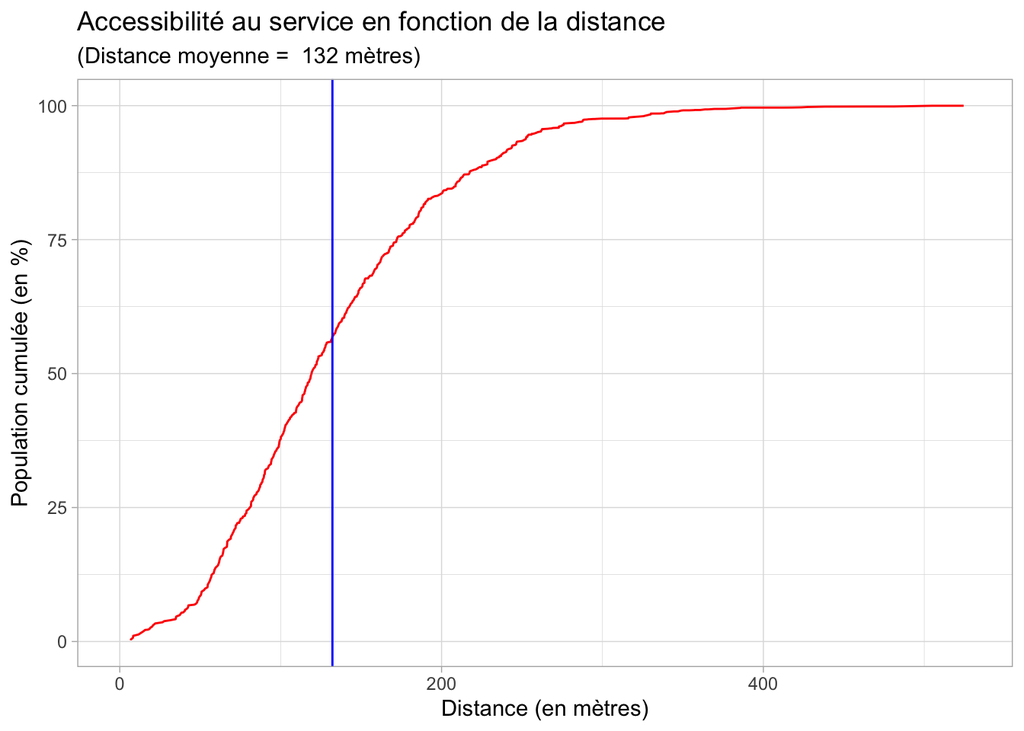

```r
selcom <- c("75105", "75106", "75107", "75113", "75114", "75115")
myequ2 <- extract_equ(equip = bpe, mycom = selcom, myproj = 2154, myequ = "D307")
mypop2 <- extract_pop(mypop = gridpop, mycom = selcom, myproj = 2154, mysize = "Ind")
graph_pop_equ_dist(mypop2, myequ2)
```

### Etape 4 : Cartographie des inégalités d’accès au service

En prenant l’accessibilité moyenne comme référence, on détermine les population situées à deux, trois ou quatre fois cette distance.

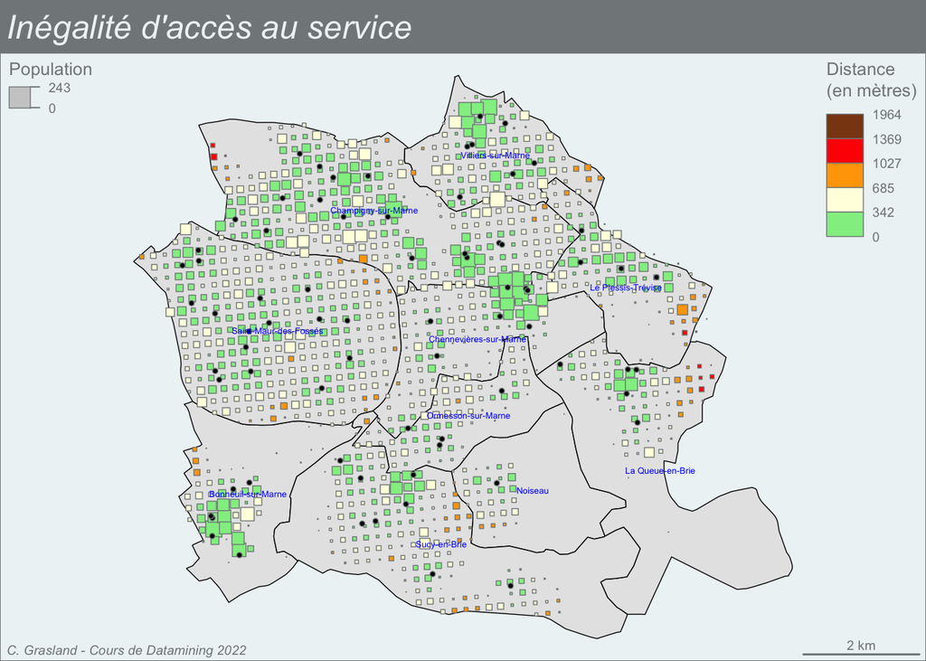

```r
mf_init(mymap, theme = "agolalight")

mf_map(mymap, theme = "agolalight", type = "base", col = "gray90", border = "black",
    add = T)

mf_map(x = mypop, var = c("Mi", "distmin"), type = "prop_choro", breaks = c(0, distmoy,
    distmoy * 2, distmoy * 3, distmoy * 4, distmax), pal = c("lightgreen", "lightyellow",
    "orange", "red", "chocolate4"), symbol = "square", inches = 0.08, leg_pos = c("topleft",
    "topright"), leg_val_rnd = c(0, 0), leg_title = c("Population", "Distance \n(en mètres)"),
    add = T)



mf_map(myequ, type = "prop", var = "Ej", symbol = "circle", inches = 0.02, col = "black",
    leg_pos = NA, )

mf_layout(title = "Inégalité d'accès au service", frame = T, credits = "C. Grasland - Cours de Datamining 2022",
    arrow = F)

mf_label(mymap, var = "NOM_COM", cex = 0.4, overlap = F, col = "blue")
```

On peut désormais repérer facilement :

- *les populations favorisées (en vert)* avec une distance inférieure à la moyenne
- *les population légèrement défavorisées (en jaune)* avec une distance comprise entre une et deux fois la moyenne.
- *les populations défavorisées (en orange)* avec uen distance deux à trois fois supérieure à la moyenne
- *les populations très défavorisées (en rouge ou brun)* avec une distance plus de trois fois supérieure à la moyenne

A titre d’exemple, la partie sud de la commune du Plessis-Trévise et la partie orientale de la commune de La-Queue-en-Brie apparaissement singulièrement mal équipées en écoles (si la base BPE est exacte). Inversement, on reprère dans le centre de Sucy-en-Brie une zone bien désservie avec deux écoles, alors même qu’il y a peu d’élèves à proximité. Ce qui s’explique sans doute par l’histoire de la commune (anciennes écoles du village construites avant le développement des grands-ensembles situés en périphérie de la commune).

### Etape 5 : création d’une fonction cartographique

```r
map_pop_equ_dist <- function(map = mymap, nommap = NA, equ = myequ, nomequ = "Equipement",
    pop = mypop, nompop = "Population", titre = "Accessibilité sociale", source = "Cours de DataMining 2022") {

    # Matrice de distance
    d <- create_matrix(x = pop, y = equ)
    pop$distmin <- apply(d, 1, min)

    # Tableau des fréquences cumulées
    tab <- st_drop_geometry(pop) %>%
        select(Mi, distmin) %>%
        arrange(distmin) %>%
        mutate(freq = 100 * Mi/sum(Mi)) %>%
        mutate(freqcum = cumsum(freq))

    # Paramètres statistiques utiles
    distmoy <- sum(tab$distmin * tab$Mi)/sum(tab$Mi)
    distmax <- max(tab$distmin)

    # Carte
    mf_init(map, theme = "agolalight")

    mf_map(map, theme = "agolalight", type = "base", col = "gray90", border = "black",
        add = T)

    mf_map(x = pop, var = c("Mi", "distmin"), type = "prop_choro", breaks = c(0,
        distmoy, distmoy * 2, distmoy * 3, distmoy * 4, distmax), pal = c("lightgreen",
        "lightyellow", "orange", "red", "chocolate4"), symbol = "square", inches = 0.08,
        leg_pos = c("topleft", "topright"), leg_val_rnd = c(0, 0), leg_title = c("Population",
            "Distance \n(en mètres)"), add = T)

    mf_map(equ, type = "prop", var = "Ej", symbol = "circle", inches = 0.02, col = "black",
        leg_pos = NA, )

    mf_layout(title = "Inégalités d'accès à l'équipement", frame = T, credits = "C. Grasland - Cours de Datamining 2022",
        arrow = F)

    mf_label(map, var = "NOM_COM", cex = 0.4, overlap = F, col = "blue")

}

# carto_pop_equ(map = mymap,equ = myequ,pop = mypop)
```

Comme d’habitude, on vérifie la fonction sur un deuxième exemple, celui des pharmacies de Paris Rive Gauche

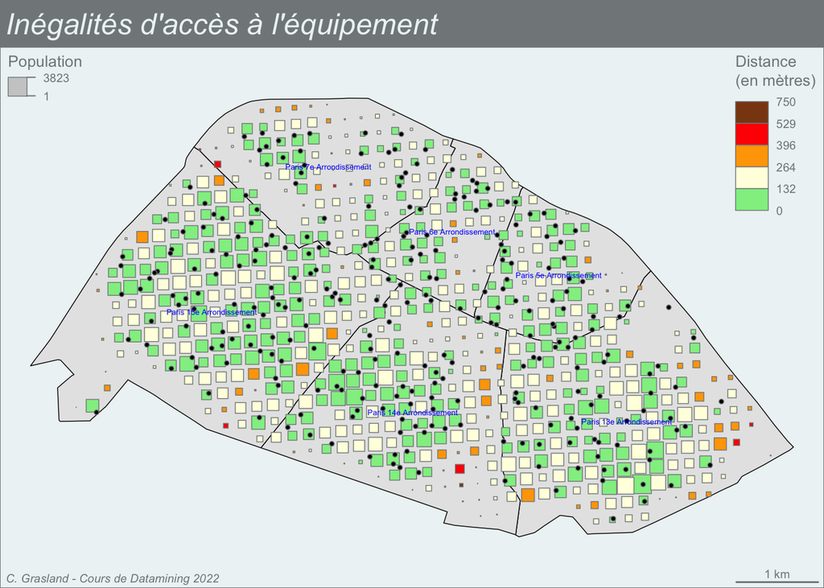

```r
selcom <- c("75105", "75106", "75107", "75113", "75114", "75115")
selequ <- "C301"
selpop <- "Ind"


mymap2 <- extract_map(mapcom = mapcom, mycom = selcom, myproj = 2154)
myequ2 <- extract_equ(equip = bpe, mycom = selcom, myproj = 2154, myequ = "D307")
mypop2 <- extract_pop(mypop = gridpop, mycom = selcom, myproj = 2154, mysize = "Ind")


map_pop_equ_dist(map = mymap2, pop = mypop2, equ = myequ2, nomequ = "Pharmacie",
    titre = "Inégalité d'accès aux lycées de Paris R.G.", source = "Source : C. Graland, cours de Data Mining 2022")
```

Bien que ce ne soit pas l’objet de l’analyse en terme de service public, on remarque quelques localisations potentiellement intéressantes sur le plan commercial. C’est notamment le cas dans le 13e arrondissement aux abords de l’avenue de France où la population a récemment augmenté. Mais il est probable que des pharmaciens avisés ont déjà saisi l’opportunité …

# **6. Création d’une application shiny**

Nous avons mis au point tout un ensemble de fonctions qui vont permettre de créer facilement une application shiny.

### Global

On commence par charger les fonctions élaborées précédemment et stockées dans le fichier access.R. Celui-ci contient également les différents packages à charger.

Puis on prépare des listes de communes, populations et équipements que l’on souhaite utiliser dans l’interface

```r
##### (1) Global ######

## Load packages and functions
source("pgm/access.R")

## Load data
base_map <- readRDS("data/mapcom.RDS")
base_pop <- readRDS("data/gridpop.RDS")
base_equ <- readRDS("data/bpe.RDS")

## Define list of choices

liste_com <- base_map$CODE_COM
names(liste_com) <- base_map$NOM_COM

liste_pop <- c("Ind", "Ind_4_5", "Ind_6_10", "Ind_11_17", "Ind_18_24")
names(liste_pop) <- c("Population totale", "Population de 4-5 ans", "Population de 6-10 ans",
    "Population de 11-17 ans", "Population de 18-24 ans")

liste_equ <- c("C101", "C104", "C201", "C301", "C302")
names(liste_equ) <- c("Ecole maternelle", "Ecole élementaire", "Collège", "Lycée d'enseignement général",
    "Lycée professionnel")
```

### Interface

On construit une page classique avec une sidebar et un mainpanel.

On introduit trois widgets pour la sélection des données et deux widgets pour le réglage de paramètres cartographiques.

```r
ui <- fluidPage(
    # Titre de l'application
    titlePanel("Les équipements scolaires des communes du Grand Paris"),

    # Définition du Widget - ici un slider en vue de construire un histogramme
    sidebarLayout(
        sidebarPanel(

## (2.1) Fonctions de choix des données
            selectInput(inputId = "com",
                        label = "Choix de la commune",
                        choices = liste_com,
                        selected = "94071",
                        multiple = TRUE
            ),

            selectInput(inputId = "equ",
                        label = "Choix de l'équipement",
                        choices = liste_equ,
                        selected = "C104"
            ),

            selectInput(inputId = "pop",
                        label = "Choix de la population concernée",
                        choices = liste_pop,
                        selected = "Ind_6_10"
            ),

## (2.2) Paramètres de visualisation
            sliderInput(inputId = "lim",
                        label = "Plage de distances : ",
                        min = 0,
                        max = 2500,
                        step = 100,
                        value = c(0,2000) ),



            sliderInput(inputId = "res",
                        label = "Précision du tracé ",
                        min = 50,
                        max = 500,
                        step = 50,
                        value = 200)
        ),
        mainPanel(
            plotOutput("mapPlot1",height = "400px"),
            plotOutput("graphPlot",height = "400px"),
            plotOutput("mapPlot2",height = "400px"),

        )
    )
)
```

### Server (version non réactive)

On construite une première version de la partie server où chaque fonction doit effectuer un prétraitement des données :

```r
server <- function(input, output) {

    output$mapPlot1 <- renderPlot({

        mymap <- extract_map(mapcom = base_map, mycom = input$com, myproj = 2154)
        myequ <- extract_equ(equip = base_equ, mycom = input$com, myproj = 2154,
            myequ = input$equ)
        step <- (input$lim[2] - input$lim[1])/10
        mybreaks <- seq(from = input$lim[1], to = input$lim[2], by = step)
        mypal <- hcl.colors(10, "Geyser")
        map_equ_dist(map = mymap, equ = myequ, myres = input$res, mybreaks = mybreaks,
            mypal = mypal)

    })

    output$graphPlot <- renderPlot({

        myequ <- extract_equ(equip = base_equ, mycom = input$com, myproj = 2154,
            myequ = input$equ)
        mypop <- extract_pop(mypop = base_pop, mycom = input$com, myproj = 2154,
            mysize = input$pop)
        graph_pop_equ_dist(pop = mypop, equ = myequ)

    })

    output$mapPlot2 <- renderPlot({

        mymap <- extract_map(mapcom = base_map, mycom = input$com, myproj = 2154)
        myequ <- extract_equ(equip = base_equ, mycom = input$com, myproj = 2154,
            myequ = input$equ)
        mypop <- extract_pop(mypop = base_pop, mycom = input$com, myproj = 2154,
            mysize = input$pop)
        map_pop_equ_dist(map = mymap, pop = mypop, equ = myequ)

    })


}
```

### Server (version réactive)

Pour éviter de refaire les même calculs on rend réactifs les tableaux partagés par plusieurs fonctions.

```r
server <- function(input, output) {

    ## (3.1) Tabelaux réactifs
    mymap <- reactive({
        tab <- extract_map(mapcom = base_map, mycom = input$com, myproj = 2154)
        return(tab)
    })

    mypop <- reactive({
        tab <- extract_pop(mypop = base_pop, mycom = input$com, myproj = 2154, mysize = input$pop)
        return(tab)
    })

    myequ <- reactive({
        tab <- extract_equ(equip = base_equ, mycom = input$com, myproj = 2154, myequ = input$equ)
        return(tab)
    })

    mybreaks <- reactive({
        step <- (input$lim[2] - input$lim[1])/10
        vec <- seq(from = input$lim[1], to = input$lim[2], by = step)
        return(vec)
    })

    ## (3.2) Fonctions graphiques
    output$mapPlot1 <- renderPlot({

        mypal <- hcl.colors(10, "Geyser")
        map_equ_dist(map = mymap(), equ = myequ(), myres = input$res, mybreaks = mybreaks(),
            mypal = mypal)

    })

    output$graphPlot <- renderPlot({

        graph_pop_equ_dist(pop = mypop(), equ = myequ())

    })

    output$mapPlot2 <- renderPlot({

        map_pop_equ_dist(map = mymap(), pop = mypop(), equ = myequ())

    })


}
```

### Améliorations possibles

On pourrait introduire un bouton qui permet de ne recalculer les cartes et graphiques que lorsque l’on a terminé la sélection des communes.

Par ailleurs on peut considérablement améliorer le design en proposant des fonctions meilleures, **sans que cela modifie la structure de l’interface shiny**. Vouspouvez par exemple revoir les couleurs par défaut des palettes…